# Course overview

30 March 2026

Who am I?

## My role as course instructor

- Help you learn the material
- Help you learn how to ask for help
- Be a future resource

Who are you?

## Introduce yourself

1. Your degree program (MS, PhD)
2. Your school/department
3. Your area of study (a phrase or short sentence)

What is this course about?

## Two major goals in ecology:

1. Infer process from pattern

Process \(\overset{?}{\Rightarrow}\) Pattern

Pattern \(= f(\)Process\()\)

Data \(= f(\)Process\()\)

Data = Process + Noise

## Ecological data often have lots of noise

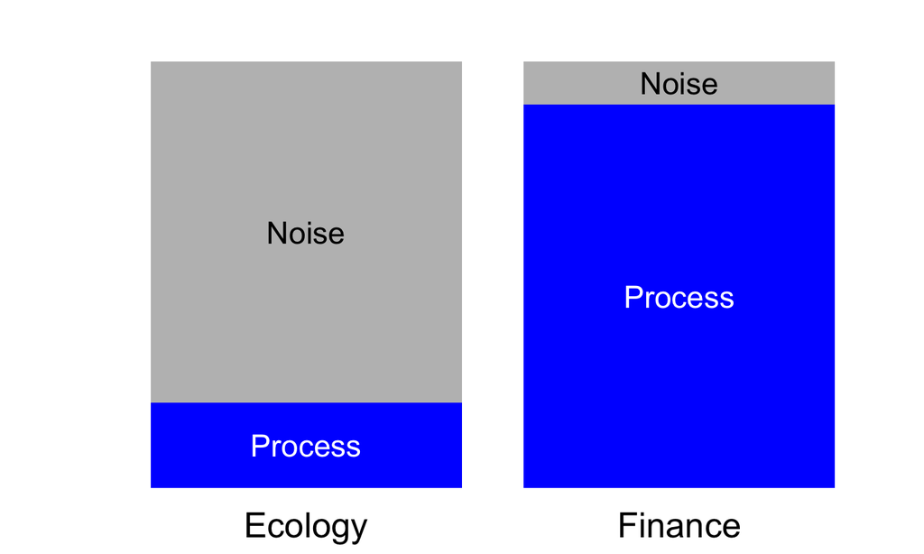

Our challenge is to separate  
the signal from the noise

## Two major goals in ecology:

1. Infer process from pattern

2. **Make predictions**

## Ecological forecasting

How will [some future scenario] affect [some ecosystem service]?

## General approach

### Question \(\rightarrow\) Data \(\rightarrow\) Model \(\rightarrow\) Inference \(\rightarrow\) Prediction

## Forms of linear models

| Errors | Single random process | Multiple random processes |
| --- | --- | --- |
| Normal | Linear Model (LM) | Linear Mixed Model (LMM) |
| Non-normal | Generalized Linear Model (GLM) | Generalized Linear Mixed Model (GLMM) |

## Forms of linear models

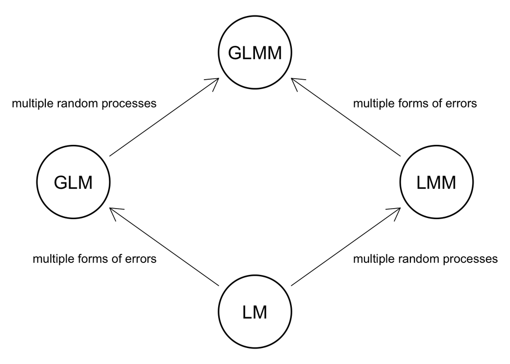

## Learning objectives for the course

By the end of the quarter, students should be able to:

- Identify an appropriate statistical model based on the data and specific question
- Understand the assumptions behind a chosen statistical model
- Use **R** to fit a variety of linear models to data
- Evaluate data support for various models and select the most parsimonious model among them
- Use **R Markdown** to combine text, equations, code, tables, and figures into reports

## Software

## R Software

### An environment for statistical computing and graphics

- It’s FREE!
- Enormous developer & support communities
- [Learn more here](https://www.r-project.org/about.html)

## R Software

- Most of R’s current capabilities come from *packages*
- We will use several different packages for fitting statistical models (eg, `nlme`, `lme4`)

## RStudio

### An integrated development environment (IDE) for R

## RStudio highlights

- Syntax highlighting, code completion, smart indentation
- Easily manage multiple working directories using projects
- Interactive debugger to diagnose and fix errors quickly
- Extensive package development tools
- Built-in tools & GUIs for git & Markdown

## RStudio benefits

[Cheat sheets](https://rstudio.com/resources/cheatsheets/)

[Webinars, links, etc](https://resources.rstudio.com/)

## R Markdown

Notebook interface to weave together text, equations, and code into nicely formatted output

Allows you to create and document fully reproducible workflows

Ideal framework for homework assignments!

## R Markdown

Supports dozens of static and dynamic output formats

- HTML
- PDF
- MS Word
- HTML5 slides
- Books
- Shiny apps
- Scientific articles
- websites

[Gallery here](https://rmarkdown.rstudio.com/gallery.html)

[**Course information**](https://qerm514.github.io/website)